# Atividade 3

Universidade Federal Rural de Pernambuco (UFRPE) Programa de Pós-Graduação em Biometria e Estatística Aplicada (PPGBEA) Uso de software na análise de dados biométricos (PBEA7331)

Docente: Antonio Samuel Alves da Silva

24 de Março de 2021

1. Carregue o conjunto de dados `HairEyeColor` com o comando

   `data(HairEyeColor)`

   e responda as seguintes perguntas fornecendo o comando no `R`: (a) Qual o total de pessoas na amostra? (b) Qual a proporção de homens e de mulheres na amostra? (c) Quantos são os homens de cabelos pretos? (d) Quantas mulheres têm cabelos loiros? (e) Qual a proporção de homens e de mulheres entre as pessoas ruivas? (f) Quantas pessoas tem olhos verdes?
2. Considere a tabela com frequências apresentadas a seguir.

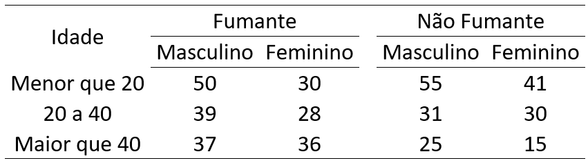

   Armazene estas informações de forma adequada em um `data.frame` e exiba comandos para respoder as perguntas que seguem: (a) Qual o número total de pessoas? (b) Qual o número de fumantes e não fumantes? (c) Quantas pessoas são do sexo masculino? (d) Quantas mulheres são não fumantes?
3. Construa uma matriz triangular superior utilizando estruturas de controle e repetição. Garanta que seus elementos sejam preenchidos com o produto de seus respectivos índices, conforme mostrado a seguir:

```
##      [,1] [,2] [,3] [,4] [,5]
## [1,]    1    2    3    4    5
## [2,]    0    4    6    8   10
## [3,]    0    0    9   12   15
## [4,]    0    0    0   16   20
## [5,]    0    0    0    0   25
```

4. Calcule as seguintes somas **sem** e **com** o uso de estrutura de repetição (`for` ou `while`).
   $$\mbox{(a)}\quad \dfrac{1}{100}\displaystyle\sum_{i=0}^{100}\left(i-50\right)^{2}\quad\quad \mbox{(b)}\quad \displaystyle\sum_{i=10}^{100}\left(i^3+4i^2\right) \quad\quad \mbox{(c)}\quad \displaystyle\sum_{i=1}^{25}\left(\frac{2^i}{i}+\frac{3^i}{i^2}\right) \quad\quad \mbox{(d)}\quad \displaystyle\sum_{i=1}^{20}\sum_{j=1}^{5}\dfrac{i^4}{3+j}$$
5. Sabe-se que se $X_{1},X_{2}\ldots,X_{n}$ é uma amostral aleatória obtida a partir de uma variável aleatória $X\sim N(\mu,\sigma^2)$, tal que a variância é conhecida, então o intervalo de confiança de nível $(1-\alpha)$ para a média populacional $\mu$ é dado por:
   $$\left(\overline{X}-z_{\alpha/2}\frac{\sigma}{\sqrt{n}};\overline{X}+z_{\alpha/2}\frac{\sigma}{\sqrt{n}}\right),$$
   em que $z_{\alpha/2}$ é o quantil da distribuição normal padrão tal que $P(Z<z_{\alpha/2})=\alpha/2$. Com base na expressão para o cálculo do intervalo de confiança para $\mu$, elaborar uma função que tenha como entrada a média amostral ($\overline{x}$), o desvio padrão populacional ($\sigma$), o tamanho da amostra ($n$) e o nível de confiança ($1-\alpha$), e retorne um vetor contendo os limites inferior e o superior do intervalo. Para média amostral, desvio padrão populacional, tamanho da amostra e nível de confiança iguais a 5, 2, 20 e 0.95, respectivamente, tem-se que o intervalo de confiança é `(4.123,5.877)`. Utilize estes valores para testar a função criada. Dica: para cálculo do valor $z_{\alpha/2}$ utilize a função `qnorm`.